# RNA-seq Analysis of Parkinson’s Disease (GSE68719)

Camille Tura–Durand

2026-06-19

**Course:** Genomics, Epigenetics and Applications  
**Teacher:** MATHEW Mano Joseph

# Introduction

Parkinson’s Disease is the second most common neurodegenerative disorder worldwide, characterized by the progressive loss of dopaminergic neurons in the substantia nigra. While the exact molecular mechanisms remain partially understood, transcriptomic studies have revealed consistent dysregulation of pathways related to mitochondrial function, oxidative stress, and protein homeostasis.

This analysis re-examines the publicly available RNA-seq dataset **GSE68719** from the NCBI Gene Expression Omnibus (GEO), which profiled post-mortem prefrontal cortex (Brodmann Area 9, BA9) tissue from Parkinson’s Disease patients and neurologically normal controls.

**Dataset summary:**

| Parameter | Details |
| --- | --- |
| GEO Accession | GSE68719 |
| Organism | *Homo sapiens* |
| Tissue | Post-mortem BA9 brain cortex |
| Parkinson’s Disease patients | 29 |
| Controls | 44 |
| Data type | RNA-seq normalized counts |

**Biological objectives:**

- Identify differentially expressed genes (DEGs) between Parkinson’s Disease and control samples
- Assess the quality and structure of the transcriptomic data
- Perform functional enrichment to link DEGs to known biological pathways
- Reproduce and extend findings from the original publication (mitochondrial dysfunction, oxidative stress, protein folding, metallothioneins)

# Load Packages

```r
# Install BiocManager if not already available (manages Bioconductor packages)
if (!requireNamespace("BiocManager", quietly = TRUE))
  install.packages("BiocManager")

# Define all required packages
packages <- c(
  "DESeq2",           # Differential expression analysis
  "tidyverse",        # Data manipulation and visualization
  "pheatmap",         # Heatmap visualization
  "RColorBrewer",     # Color palettes
  "clusterProfiler",  # Functional enrichment analysis (GO, KEGG)
  "enrichplot",       # Visualization of enrichment results (emapplot, dotplot...)
  "org.Hs.eg.db",    # Human genome annotation database
  "AnnotationDbi",    # Interface for annotation databases
  "EnhancedVolcano",  # Publication-ready volcano plots
  "ggrepel"           # Non-overlapping labels in ggplot2
)

# Install any missing packages automatically
for (pkg in packages) {
  if (!requireNamespace(pkg, quietly = TRUE)) {
    BiocManager::install(pkg, ask = FALSE)
  }
}

# Load all libraries
library(DESeq2)
library(tidyverse)
library(pheatmap)
library(RColorBrewer)
library(clusterProfiler)
library(enrichplot)       # Required for emapplot() and pairwise_termsim()
library(org.Hs.eg.db)
library(AnnotationDbi)
library(EnhancedVolcano)
library(ggrepel)

# Set a clean default theme for all ggplot2 figures
theme_set(theme_bw())

# Configure knitr to save all figures as PNG in figure-html/
knitr::opts_chunk$set(
  fig.path = "figure-html/",
  dev      = "png",
  dpi      = 150,
  fig.keep = "all"
)

# Create the output directory if it does not already exist
dir.create(
  "figure-html",
  recursive    = TRUE,
  showWarnings = FALSE
)
```

# Data Import

```r
# Define the path to the count matrix relative to this Rmd file
# The data file must be placed in the same directory as this Rmd document
data_file <- "GSE68719_mlpd_PCG_DESeq2_norm_counts.txt.gz"

# Stop with an informative message if the file is not found
if (!file.exists(data_file)) {
  stop(
    "Data file not found: ", data_file,
    "\nPlease place the file in the same directory as this Rmd document."
  )
}

# Load the GEO-provided normalized count matrix
# The file is gzip-compressed (.gz), read.table handles it via gzfile()
counts <- read.table(
  gzfile(data_file),
  header      = TRUE,
  sep         = "\t",
  row.names   = 1,
  check.names = FALSE
)

# Check dimensions: rows = genes, columns = samples
dim(counts)
```

```
## [1] 17580    74
```

```r
# Preview the first few rows and columns
head(counts[, 1:5])
```

```
##                      symbol      C_0002     C_0003     C_0004     C_0005
## ENSG00000000003.10   TSPAN6 304.2094614 294.583928 244.632298 215.822826
## ENSG00000000005.5      TNMD   0.7330348   2.283596   6.961082   2.480722
## ENSG00000000419.8      DPM1 571.0341456 545.779526 563.847615 586.442713
## ENSG00000000457.8     SCYL3 150.2721436 162.135340 172.038161 176.131272
## ENSG00000000460.12 C1orf112 144.4078648 150.717359 139.221633 100.717319
## ENSG00000000938.8       FGR 315.9380189 290.016736 229.715695 184.069582
```

> **Note on the data:** The dataset contains **DESeq2-normalized** RNA-seq counts (not raw counts). While DESeq2 internally expects integer counts, we round these normalized values to integers to run the differential expression pipeline. This is a known limitation of re-analyzing GEO-processed data and will be discussed further.

# Metadata Construction

```r
# Keep only numeric columns (exclude any annotation columns if present)
counts_numeric <- counts %>%
  dplyr::select(where(is.numeric))

# Extract sample names from the numeric matrix
sample_names <- colnames(counts_numeric)

# Build a metadata (colData) dataframe automatically based on sample name prefixes:
# Samples starting with "C_" are Controls, all others are Parkinson's Disease patients
sample_info <- data.frame(
  sample    = sample_names,
  condition = ifelse(grepl("^C_", sample_names), "Control", "PD")
)

rownames(sample_info) <- sample_info$sample

# Verify the group assignment: confirm both groups are present and counts match
# the dataset description (29 Parkinson's Disease patients, 44 controls)
group_counts <- table(sample_info$condition)
cat("Sample group sizes:\n")
```

```
## Sample group sizes:
```

```r
print(group_counts)
```

```
##
## Control      PD
##      44      29
```

```r
# Cross-check: stop if neither group is detected, which would indicate
# that the C_ prefix convention has changed in the GEO file
if (!all(c("Control", "PD") %in% names(group_counts))) {
  stop("Expected groups 'Control' and 'PD' not found. Check sample name prefixes.")
}

# Summary of group sizes
table(sample_info$condition)
```

```
##
## Control      PD
##      44      29
```

```r
# Preview metadata
head(sample_info)
```

```
##        sample condition
## C_0002 C_0002   Control
## C_0003 C_0003   Control
## C_0004 C_0004   Control
## C_0005 C_0005   Control
## C_0006 C_0006   Control
## C_0008 C_0008   Control
```

> **Metadata:** The condition label is inferred from sample name prefixes (`C_` = Control, others = Parkinson’s Disease). This avoids manual annotation errors and is consistent with the original GEO submission.

# Count Matrix Preparation

```r
# Convert the dataframe to a numeric matrix
counts_matrix <- as.matrix(counts_numeric)

# Ensure all values are numeric (handles potential import issues)
counts_matrix <- apply(counts_matrix, 2, as.numeric)

# Restore gene names as row names (lost during apply())
rownames(counts_matrix) <- rownames(counts)

# Round to nearest integer: required by DESeq2 which expects count data
counts_matrix <- round(counts_matrix)
mode(counts_matrix) <- "integer"

# Confirm final dimensions
dim(counts_matrix)
```

```
## [1] 17580    73
```

# DESeq2 Object Creation

```r
# Create a DESeqDataSet object from the count matrix and metadata
# design = ~condition specifies that we model gene expression as a function of condition (Parkinson's Disease vs Control)
dds <- DESeqDataSetFromMatrix(
  countData = counts_matrix,
  colData   = sample_info,
  design    = ~ condition
)
# Set "Control" as the reference level so that fold changes are computed as Parkinson's Disease vs Control
dds$condition <- relevel(dds$condition, ref = "Control")

dds
```

```
## class: DESeqDataSet
## dim: 17580 73
## metadata(1): version
## assays(1): counts
## rownames(17580): ENSG00000000003.10 ENSG00000000005.5 ...
##   ENSG00000271605.1 ENSG00000271698.1
## rowData names(0):
## colnames(73): C_0002 C_0003 ... P_0135 P_0136
## colData names(2): sample condition
```

# Filtering Low-Count Genes

```r
# Retain only genes with at least 10 counts in at least 5 samples
# This removes uninformative, very lowly expressed genes
# Improves statistical power and reduces multiple testing burden
keep <- rowSums(counts(dds) >= 10) >= 5
dds  <- dds[keep, ]

# Report how many genes remain after filtering
cat("Number of genes retained after filtering:", nrow(dds), "\n")
```

```
## Number of genes retained after filtering: 16601
```

> **Filtering rationale:** Genes with very low or zero counts across most samples provide no useful signal and inflate the number of statistical tests. Removing them improves power and reduces false discovery rate (FDR) inflation.

# Differential Expression Analysis

```r
# Run the full DESeq2 pipeline:
# 1. Estimation of size factors (normalization)
# 2. Estimation of dispersions
# 3. Negative binomial GLM fitting and Wald test
dds <- DESeq(dds)
```

```
## -- replacing outliers and refitting for 397 genes
## -- DESeq argument 'minReplicatesForReplace' = 7
## -- original counts are preserved in counts(dds)
```

```r
# Extract results for the contrast Parkinson's Disease vs Control
res <- results(
  dds,
  contrast = c("condition", "PD", "Control")
)

# Global summary: how many genes are up/down regulated?
summary(res)
```

```
##
## out of 16601 with nonzero total read count
## adjusted p-value < 0.1
## LFC > 0 (up)       : 4188, 25%
## LFC < 0 (down)     : 4449, 27%
## outliers [1]       : 0, 0%
## low counts [2]     : 0, 0%
## (mean count < 1)
## [1] see 'cooksCutoff' argument of ?results
## [2] see 'independentFiltering' argument of ?results
```

> **Note on model design:** The DESeq2 model uses `~ condition` as its only term, which directly tests the effect of Parkinson’s Disease versus Control. Ideally, known confounding variables such as age, sex, or post-mortem interval would be included as additional covariates (example: `~ age + sex + PMI + condition`) to control for inter-individual variability unrelated to disease status. The GSE68719 GEO submission does not provide complete, standardised sample-level metadata, making it impossible to include these factors reliably. As a consequence, some of the detected DEGs may reflect confounding rather than disease-specific effects; this is acknowledged as a limitation and discussed in the relevant section below.

# Results Table Preparation

```r
# Sort results by adjusted p-value (most significant first)
resOrdered <- res[order(res$padj), ]

# Convert to dataframe and add ENSEMBL ID as a column
res_df <- as.data.frame(resOrdered)
res_df$ENSEMBL <- rownames(res_df)

head(res_df)
```

```
##                     baseMean log2FoldChange     lfcSE     stat       pvalue
## ENSG00000204389.7 10729.6368       3.018058 0.3459320 8.724426 2.675347e-18
## ENSG00000132002.3  7226.0158       2.240005 0.2622220 8.542400 1.314628e-17
## ENSG00000149257.9  1132.2971       2.715132 0.3175525 8.550185 1.228919e-17
## ENSG00000123689.5   129.2779       2.437820 0.2921860 8.343382 7.219534e-17
## ENSG00000204388.5  8799.6572       2.505850 0.3004285 8.340921 7.371423e-17
## ENSG00000106211.8  9615.2546       2.292765 0.2842400 8.066299 7.246110e-16
##                           padj           ENSEMBL
## ENSG00000204389.7 4.441343e-14 ENSG00000204389.7
## ENSG00000132002.3 7.274713e-14 ENSG00000132002.3
## ENSG00000149257.9 7.274713e-14 ENSG00000149257.9
## ENSG00000123689.5 2.447460e-13 ENSG00000123689.5
## ENSG00000204388.5 2.447460e-13 ENSG00000204388.5
## ENSG00000106211.8 1.725632e-12 ENSG00000106211.8
```

# ENSEMBL ID Cleaning

```r
# ENSEMBL IDs from GEO often include version numbers (e.g., ENSG00000139618.2)
# Annotation databases (org.Hs.eg.db) require IDs without version suffixes
# We use gsub() to remove everything after the dot
res_df$ENSEMBL_clean <- gsub("\\..*", "", res_df$ENSEMBL)

# Verify the cleaning worked correctly
head(res_df$ENSEMBL_clean)
```

```
## [1] "ENSG00000204389" "ENSG00000132002" "ENSG00000149257" "ENSG00000123689"
## [5] "ENSG00000204388" "ENSG00000106211"
```

> **Example:** `ENSG00000139618.2` → `ENSG00000139618`

# Gene Annotation

```r
# Map ENSEMBL IDs to gene symbols, full gene names, and Entrez IDs
# These are needed for readable plots and functional enrichment
annotations <- AnnotationDbi::select(
  org.Hs.eg.db,
  keys    = unique(res_df$ENSEMBL_clean),
  columns = c("SYMBOL", "GENENAME", "ENTREZID"),
  keytype = "ENSEMBL"
)
# Remove duplicated ENSEMBL entries (some genes map to multiple symbols)
annotations <- annotations[!duplicated(annotations$ENSEMBL), ]

# Merge annotation with DESeq2 results
res_annot <- merge(
  res_df,
  annotations,
  by.x = "ENSEMBL_clean",
  by.y = "ENSEMBL"
)

head(res_annot)
```

```
##     ENSEMBL_clean   baseMean log2FoldChange      lfcSE       stat       pvalue
## 1 ENSG00000000003 348.118849     0.25413775 0.15214412  1.6703752 9.484516e-02
## 2 ENSG00000000005   4.545732    -0.85944428 0.29060194 -2.9574623 3.101826e-03
## 3 ENSG00000000419 692.331382    -0.23396080 0.10359599 -2.2583964 2.392096e-02
## 4 ENSG00000000457 179.896853    -0.36087227 0.09145837 -3.9457543 7.954915e-05
## 5 ENSG00000000460 140.072872     0.05042003 0.10287274  0.4901204 6.240487e-01
## 6 ENSG00000000938 284.518316     0.99797191 0.18871734  5.2881833 1.235371e-07
##           padj            ENSEMBL SYMBOL
## 1 1.621216e-01 ENSG00000000003.10 TSPAN6
## 2 1.032781e-02  ENSG00000000005.5   TNMD
## 3 5.316801e-02  ENSG00000000419.8   DPM1
## 4 6.066125e-04  ENSG00000000457.8  SCYL3
## 5 7.141757e-01 ENSG00000000460.12  FIRRM
## 6 5.467652e-06  ENSG00000000938.8    FGR
##                                                      GENENAME ENTREZID
## 1                                               tetraspanin 6     7105
## 2                                                 tenomodulin    64102
## 3 dolichyl-phosphate mannosyltransferase subunit 1, catalytic     8813
## 4                                    SCY1 like pseudokinase 3    57147
## 5   FIGNL1 interacting regulator of recombination and mitosis    55732
## 6              FGR proto-oncogene, Src family tyrosine kinase     2268
```

# Significant DEG Selection

```r
# Apply significance thresholds:
# - Adjusted p-value < 0.05 (FDR-corrected via Benjamini-Hochberg)
# - |log2FoldChange| > 1 (i.e., at least 2-fold change between groups)
sig_genes <- res_annot %>%
  filter(
    !is.na(padj),
    padj < 0.05,
    abs(log2FoldChange) > 1
  )

cat("Number of significant DEGs:", nrow(sig_genes), "\n")
```

```
## Number of significant DEGs: 534
```

```r
cat("  Upregulated in Parkinson's Disease:", sum(sig_genes$log2FoldChange > 1), "\n")
```

```
##   Upregulated in Parkinson's Disease: 383
```

```r
cat("  Downregulated in Parkinson's Disease:", sum(sig_genes$log2FoldChange < -1), "\n")
```

```
##   Downregulated in Parkinson's Disease: 151
```

> **Significance thresholds:** A gene is considered differentially expressed if its Benjamini-Hochberg adjusted p-value is below 0.05 and its absolute log2 fold change exceeds 1. This second criterion corresponds to a minimum two-fold difference in expression between groups, a magnitude widely regarded as biologically meaningful in transcriptomic studies.

# Variance Stabilization

```r
# VST = Variance Stabilizing Transformation
# Transforms raw counts to stabilize variance across the range of mean expression
# Needed for PCA and heatmaps (which assume approximately homoscedastic data)
# blind = FALSE: uses the experimental design for dispersion estimation (more accurate)
vsd <- vst(dds, blind = FALSE)
```

# Count Distribution: Before and After Normalization

## Before Normalization

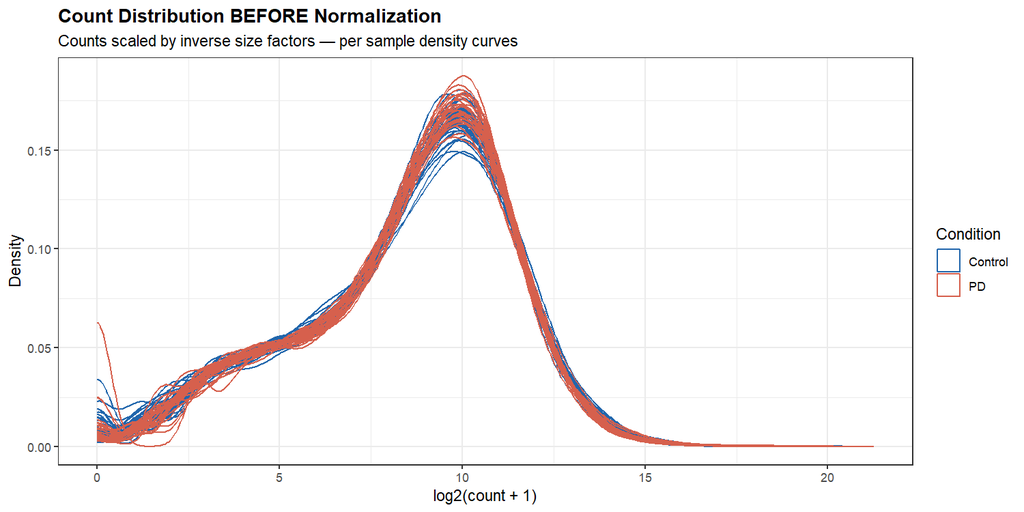

```r
# The GEO dataset provides pre-normalized counts, so we cannot recover true raw counts.
# To produce a meaningful BEFORE/AFTER comparison, we simulate unnormalized counts by
# multiplying each sample's counts by the inverse of its DESeq2 size factor.
# This reintroduces the library-size differences that normalization removes, making
# the before/after contrast visually clear and biologically meaningful.

# Estimate size factors (already done inside DESeq() but we recompute for clarity)
dds_sf <- estimateSizeFactors(dds)
sf     <- sizeFactors(dds_sf)

# Divide each sample's counts by its size factor to get unnormalized-equivalent counts
counts_norm   <- counts(dds_sf, normalized = TRUE)   # DESeq2 normalized
counts_unnorm <- sweep(counts_norm, 2, sf, FUN = "*") # reintroduce library-size differences

# Log2 transform
log2_unnorm <- log2(counts_unnorm + 1)

# Reshape to long format
unnorm_df <- as.data.frame(log2_unnorm) %>%
  rownames_to_column("gene") %>%
  pivot_longer(-gene, names_to = "sample", values_to = "log2_count") %>%
  left_join(
    data.frame(sample = rownames(sample_info), condition = sample_info$condition),
    by = "sample"
  )

ggplot(unnorm_df, aes(x = log2_count, color = condition, group = sample)) +
  geom_density(linewidth = 0.5, alpha = 0.6) +
  scale_color_manual(values = c("Control" = "#2166AC", "PD" = "#D6604D")) +
  labs(
    title    = "Count Distribution BEFORE Normalization",
    subtitle = "Counts scaled by inverse size factors — per sample density curves",
    x        = "log2(count + 1)",
    y        = "Density",
    color    = "Condition"
  ) +
  theme(plot.title = element_text(face = "bold"))
```

## After Normalization (VST)

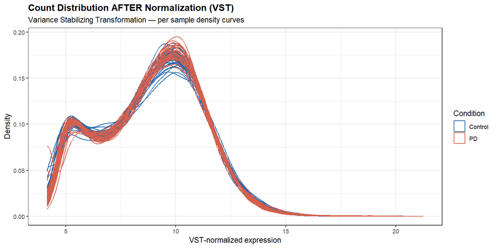

**Figure: Count distribution AFTER normalization (VST).** After Variance Stabilizing Transformation, all sample curves align tightly, confirming that technical library-size differences have been corrected. Samples can now be compared directly.

```r
# VST-normalized expression matrix (computed earlier)
vst_counts <- assay(vsd)

# Reshape to long format
vst_df <- as.data.frame(vst_counts) %>%
  rownames_to_column("gene") %>%
  pivot_longer(-gene, names_to = "sample", values_to = "vst_value") %>%
  left_join(
    data.frame(sample = rownames(sample_info), condition = sample_info$condition),
    by = "sample"
  )

ggplot(vst_df, aes(x = vst_value, color = condition, group = sample)) +
  geom_density(linewidth = 0.5, alpha = 0.6) +
  scale_color_manual(values = c("Control" = "#2166AC", "PD" = "#D6604D")) +
  labs(
    title    = "Count Distribution AFTER Normalization (VST)",
    subtitle = "Variance Stabilizing Transformation — per sample density curves",
    x        = "VST-normalized expression",
    y        = "Density",
    color    = "Condition"
  ) +
  theme(plot.title = element_text(face = "bold"))
```

# PCA Plot

```r
# Extract PCA coordinates from the VST-transformed data
pcaData <- plotPCA(vsd, intgroup = "condition", returnData = TRUE)
```

```
## using ntop=500 top features by variance
```

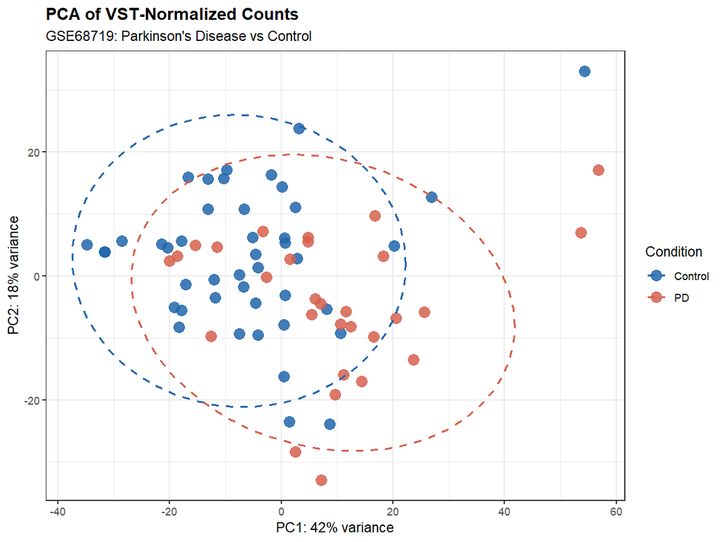

```r
# Retrieve the percentage of variance explained by each principal component
percentVar <- round(100 * attr(pcaData, "percentVar"))

# Plot with ggplot2
ggplot(pcaData, aes(PC1, PC2, color = condition)) +
  geom_point(size = 4, alpha = 0.85) +
  scale_color_manual(values = c("Control" = "#2166AC", "PD" = "#D6604D")) +
  stat_ellipse(aes(group = condition), linetype = "dashed", linewidth = 0.7) +
  labs(
    title    = "PCA of VST-Normalized Counts",
    subtitle = "GSE68719: Parkinson's Disease vs Control",
    x        = paste0("PC1: ", percentVar[1], "% variance"),
    y        = paste0("PC2: ", percentVar[2], "% variance"),
    color    = "Condition"
  ) +
  theme(plot.title = element_text(face = "bold"))
```

> **Interpretation:** Principal Component Analysis (PCA) reduces the high-dimensional transcriptome to its main axes of variation. If Parkinson’s Disease and control samples separate along PC1 or PC2, it confirms that disease state is the primary driver of expression differences. Ellipses show the 95% confidence region for each group. Outlier samples, if any, may indicate technical issues or extreme biological variability.

# Sample Distance Heatmap

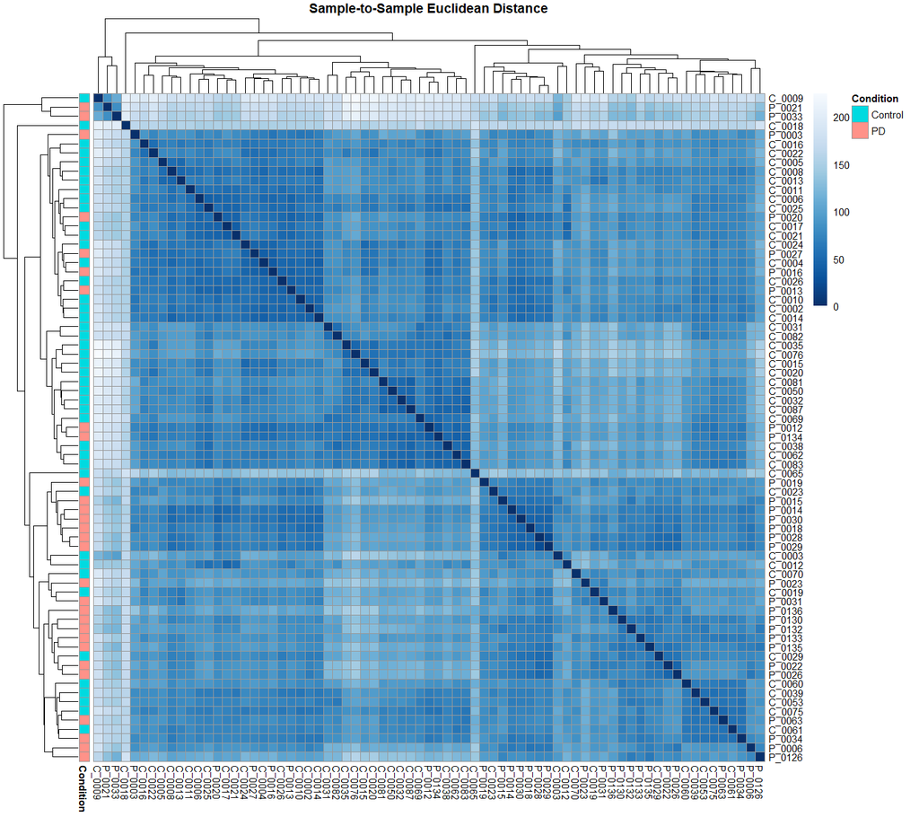

**Figure 2: Sample-to-sample distance heatmap.** Euclidean distances computed on VST-normalized counts. Darker blue indicates greater similarity. Samples within the same condition are expected to cluster together, validating the quality and consistency of the experimental groups.

```r
# Compute pairwise Euclidean distances between all samples
sampleDists       <- dist(t(assay(vsd)))
sampleDistMatrix  <- as.matrix(sampleDists)

rownames(sampleDistMatrix) <- colnames(vsd)
colnames(sampleDistMatrix) <- colnames(vsd)

# Color gradient from white (similar) to dark blue (dissimilar)
colors <- colorRampPalette(rev(brewer.pal(9, "Blues")))(255)

# Define annotation bar (condition label per sample)
annotation_row <- data.frame(Condition = colData(vsd)$condition)
rownames(annotation_row) <- colnames(vsd)

pheatmap(
  sampleDistMatrix,
  clustering_distance_rows = sampleDists,
  clustering_distance_cols = sampleDists,
  col                      = colors,
  annotation_row           = annotation_row,
  fontsize                 = 7,
  main                     = "Sample-to-Sample Euclidean Distance"
)
```

> **Interpretation:** This heatmap is a quality control step. Samples with similar transcriptomic profiles appear as darker blocks along the diagonal. Clear clustering by condition (Parkinson’s Disease vs Control) indicates good reproducibility within groups and meaningful biological signal between groups. Unexpected cross-group similarity could flag outlier or mislabeled samples.

# Distribution of Log2 Fold Changes

```r
# Apply LFC shrinkage using the 'normal' method (built into DESeq2, no extra package needed)
# The 'normal' method uses a zero-centered normal prior to shrink noisy fold change estimates
# for low-count genes toward zero — correcting the inflated LFCs that were the issue
# with the original unshrunken plot.
# It does NOT change which genes are significant — only the fold change point estimate.
# (Alternative: type="apeglm" gives better performance but requires the apeglm package:
#  BiocManager::install("apeglm"))
res_shrunk <- lfcShrink(
  dds,
  contrast = c("condition", "PD", "Control"),
  type     = "normal"
)
```

```
## using 'normal' for LFC shrinkage, the Normal prior from Love et al (2014).
##
## Note that type='apeglm' and type='ashr' have shown to have less bias than type='normal'.
## See ?lfcShrink for more details on shrinkage type, and the DESeq2 vignette.
## Reference: https://doi.org/10.1093/bioinformatics/bty895
```

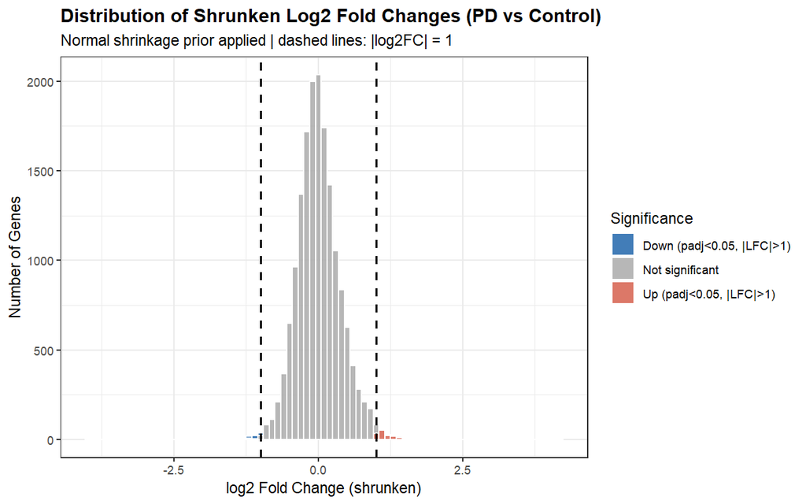

**Figure: Distribution of shrunken log2 fold changes.** Histogram of log2FC values for all tested genes, colored by significance status. Shrunken fold changes (normal method) are used to correct the inflated fold change estimates that arise for low-count genes. The distribution should be roughly centered on 0. Genes with |log2FC| > 1 and padj < 0.05 (significant DEGs) are highlighted in red/blue; non-significant genes are shown in grey.

```r
# Build a dataframe for plotting with significance annotation
# We join with the original res to recover padj (lfcShrink with normal keeps padj)
lfc_data <- as.data.frame(res_shrunk) %>%
  filter(!is.na(log2FoldChange), !is.na(padj)) %>%
  mutate(
    significance = case_when(
      padj < 0.05 & log2FoldChange >  1 ~ "Up (padj<0.05, |LFC|>1)",
      padj < 0.05 & log2FoldChange < -1 ~ "Down (padj<0.05, |LFC|>1)",
      TRUE                               ~ "Not significant"
    )
  )

ggplot(lfc_data, aes(x = log2FoldChange, fill = significance)) +
  geom_histogram(binwidth = 0.1, color = "white", alpha = 0.85) +
  scale_fill_manual(
    values = c(
      "Up (padj<0.05, |LFC|>1)"   = "#D6604D",
      "Down (padj<0.05, |LFC|>1)" = "#2166AC",
      "Not significant"            = "#AAAAAA"
    )
  ) +
  geom_vline(xintercept = c(-1, 1), color = "black", linetype = "dashed", linewidth = 0.8) +
  labs(
    title    = "Distribution of Shrunken Log2 Fold Changes (PD vs Control)",
    subtitle = "Normal shrinkage prior applied | dashed lines: |log2FC| = 1",
    x        = "log2 Fold Change (shrunken)",
    y        = "Number of Genes",
    fill     = "Significance"
  ) +
  theme(plot.title = element_text(face = "bold"))
```

> **Interpretation:** LFC shrinkage (normal prior method) corrects the artificially large fold change estimates that arise for genes with very low counts, where sampling noise can produce extreme but unreliable ratios. After shrinkage, the distribution is more tightly centred on 0, reflecting the true biological signal rather than statistical noise. Significant upregulated genes (red) and downregulated genes (blue) are coloured explicitly to distinguish them from the large pool of non-significant genes (grey). A symmetric distribution around 0 confirms that the normalization and model are unbiased.

# MA Plot

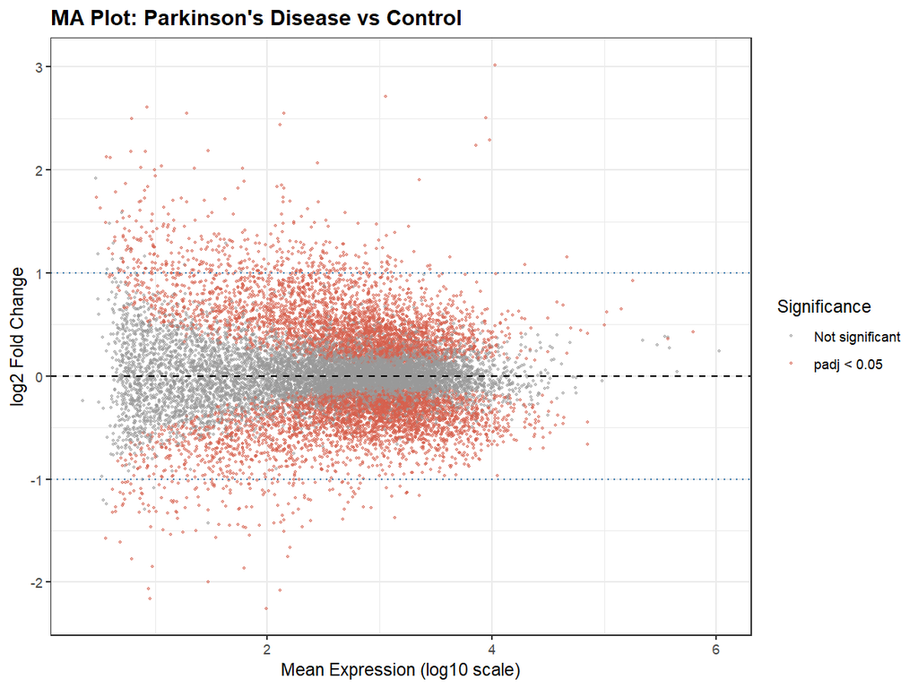

**Figure 4: MA plot.** Log2 fold change (M) versus mean expression (A = average normalized counts, log scale). Each dot is one gene. Significant genes (padj < 0.05) are colored in red. The horizontal line at y = 0 represents no change. Genes with very low average expression (left side) tend to show higher fold change variability, a known property of count-based data.

```r
# Prepare data for MA plot
ma_data <- as.data.frame(res) %>%
  filter(!is.na(padj), !is.na(log2FoldChange)) %>%
  mutate(significant = padj < 0.05)

ggplot(ma_data, aes(x = log10(baseMean + 1), y = log2FoldChange, color = significant)) +
  geom_point(size = 0.6, alpha = 0.5) +
  scale_color_manual(values = c("FALSE" = "grey60", "TRUE" = "#D6604D"),
                     labels = c("Not significant", "padj < 0.05")) +
  geom_hline(yintercept = 0, color = "black", linetype = "dashed") +
  geom_hline(yintercept = c(-1, 1), color = "steelblue", linetype = "dotted") +
  labs(
    title  = "MA Plot: Parkinson's Disease vs Control",
    x      = "Mean Expression (log10 scale)",
    y      = "log2 Fold Change",
    color  = "Significance"
  ) +
  theme(plot.title = element_text(face = "bold"))
```

> **Interpretation:** The MA plot is a standard visualization in differential expression analysis. It allows assessment of whether significant genes span the full range of expression levels or are restricted to highly abundant transcripts. It also reveals potential heteroscedasticity, meaning higher variance among lowly expressed genes, a known property of count-based data. To stabilize fold change estimates at low expression levels, a shrinkage method (example: apeglm) could be applied, although it is not required for significance testing.

# Volcano Plot

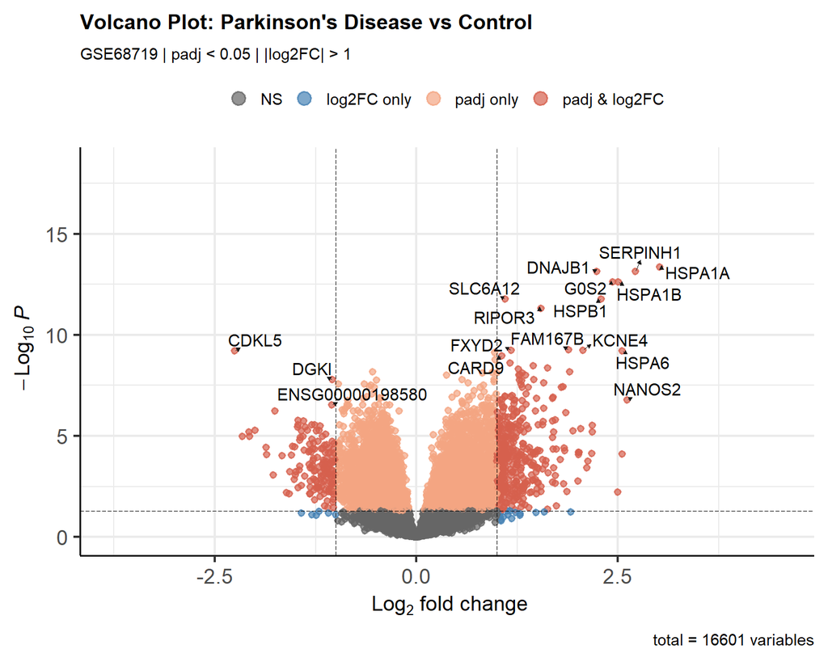

```r
EnhancedVolcano(
  res_annot,
  lab      = ifelse(is.na(res_annot$SYMBOL), res_annot$ENSEMBL_clean, res_annot$SYMBOL),
  x        = "log2FoldChange",
  y        = "padj",
  pCutoff  = 0.05,
  FCcutoff = 1,
  title    = "Volcano Plot: Parkinson's Disease vs Control",
  subtitle = "GSE68719 | padj < 0.05 | |log2FC| > 1",
  col      = c("grey40", "steelblue", "#F4A582", "#D6604D"),
  colAlpha = 0.7,
  legendLabels = c("NS", "log2FC only", "padj only", "padj & log2FC"),
  drawConnectors = TRUE,
  widthConnectors = 0.3
)
```

> **Interpretation:** The volcano plot simultaneously visualizes statistical significance and biological effect size. Genes in the upper-right quadrant are significantly upregulated in Parkinson’s Disease; those in the upper-left are significantly downregulated. Genes labeled in this plot are of highest biological interest for follow-up. Note that biological significance (effect size) and statistical significance are not equivalent and must both be considered.

# Heatmap of Top Differentially Expressed Genes

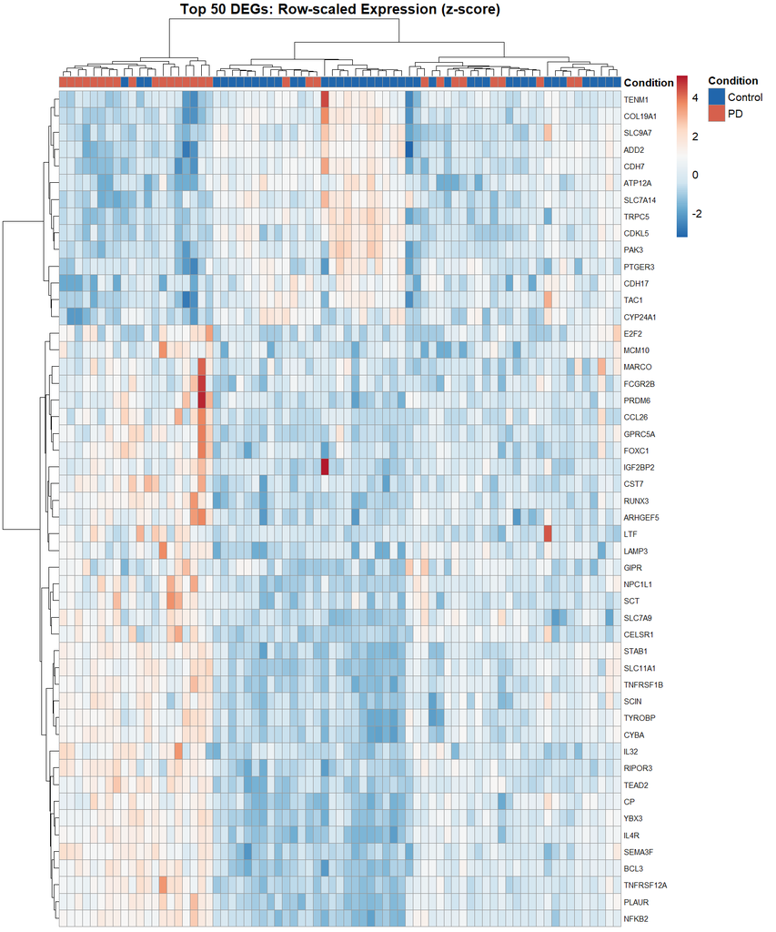

**Figure 6: Heatmap of the top 50 significant DEGs.** Rows = genes (labeled by gene symbol), columns = samples. Expression values are row-scaled (z-score) so that relative expression patterns across conditions are visible. Red = high expression, blue = low expression. Samples are annotated by condition (Parkinson’s Disease vs Control) on top.

```r
# Gene selection rationale: the top 50 DEGs are selected by adjusted p-value
# (smallest padj first) among genes passing both thresholds (padj < 0.05, |log2FC| > 1).
# This prioritises statistical confidence while keeping the heatmap readable.
# Using padj rather than log2FC for ranking avoids selecting extreme but noisy fold changes.
topgenes <- head(sig_genes$ENSEMBL, 50)

# Keep only genes present in the VST object
topgenes <- topgenes[topgenes %in% rownames(vsd)]

# Extract VST expression matrix for those genes
mat <- assay(vsd)[topgenes, ]

# Build a mapping from ENSEMBL ID to gene SYMBOL for row labels
# sig_genes already has both ENSEMBL and SYMBOL columns from the annotation step
symbol_map <- sig_genes %>%
  dplyr::select(ENSEMBL, SYMBOL) %>%
  distinct() %>%
  filter(ENSEMBL %in% topgenes)

# Create a named vector: ENSEMBL -> SYMBOL (fall back to ENSEMBL if symbol is NA)
row_labels <- setNames(
  ifelse(is.na(symbol_map$SYMBOL) | symbol_map$SYMBOL == "",
         symbol_map$ENSEMBL,
         symbol_map$SYMBOL),
  symbol_map$ENSEMBL
)

# Reorder to match the matrix row order; use ENSEMBL as fallback for any missing mapping
row_labels_ordered <- ifelse(
  rownames(mat) %in% names(row_labels),
  row_labels[rownames(mat)],
  rownames(mat)
)

# Row-wise z-score scaling (centers and scales gene expression)
mat_scaled <- t(scale(t(mat)))

# Annotation for columns (samples): show condition
annotation_col <- data.frame(Condition = colData(vsd)$condition)
rownames(annotation_col) <- colnames(mat)

# Custom colors for condition annotation
ann_colors <- list(Condition = c(Control = "#2166AC", PD = "#D6604D"))

pheatmap(
  mat_scaled,
  annotation_col    = annotation_col,
  annotation_colors = ann_colors,
  show_rownames     = TRUE,
  show_colnames     = FALSE,
  labels_row        = row_labels_ordered,   # Gene symbols instead of ENSEMBL IDs
  fontsize_row      = 7,
  fontsize_col      = 7,
  scale             = "none",   # already scaled above
  color             = colorRampPalette(rev(brewer.pal(7, "RdBu")))(100),
  clustering_method = "ward.D2",
  main              = "Top 50 DEGs: Row-scaled Expression (z-score)"
)
```

> **Interpretation:** The heatmap reveals whether the top DEGs cluster samples according to disease condition. A clear color separation between Parkinson’s Disease (right/left) and control samples confirms that these genes discriminate the two groups. Ward’s linkage clustering (`ward.D2`) is used as it tends to produce more compact, interpretable clusters than single or complete linkage.

# P-value Distribution

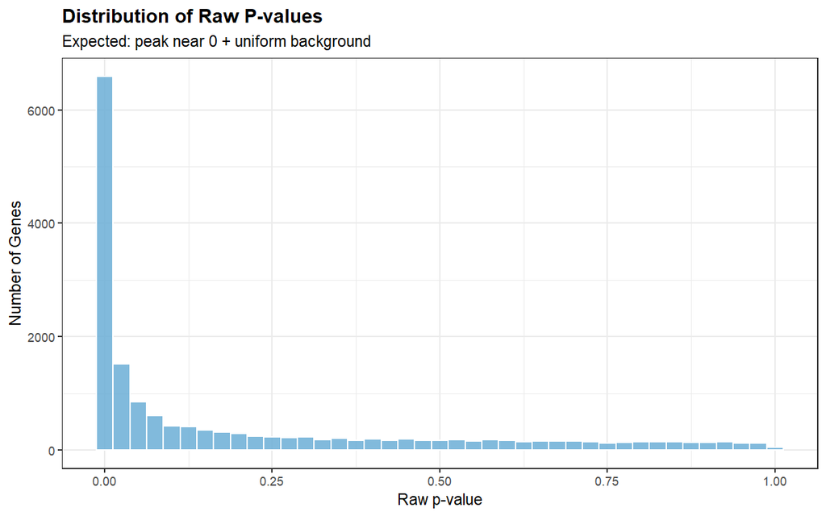

**Figure 7: Distribution of raw p-values.** A well-calibrated differential expression analysis should produce a distribution with a peak near 0 (true positives) and a roughly uniform distribution for higher p-values (null genes). A sharp anti-conservative peak near 0 confirms that real signal is present in the data.

```r
pval_data <- as.data.frame(res) %>%
  filter(!is.na(pvalue))

ggplot(pval_data, aes(x = pvalue)) +
  geom_histogram(binwidth = 0.025, fill = "#6BAED6", color = "white", alpha = 0.85) +
  labs(
    title    = "Distribution of Raw P-values",
    subtitle = "Expected: peak near 0 + uniform background",
    x        = "Raw p-value",
    y        = "Number of Genes"
  ) +
  theme(plot.title = element_text(face = "bold"))
```

> **Interpretation:** This plot is a key quality control step. A bimodal distribution with a strong peak near p = 0 and an approximately flat tail indicates proper model fit and the presence of true biological signal. An inflation near p = 1 could suggest model misspecification or a large proportion of low-count genes (which is why filtering was applied earlier).

# GO Enrichment Analysis

```r
# Extract Entrez IDs for significantly upregulated genes in Parkinson's Disease
genes_up <- sig_genes %>%
  filter(log2FoldChange > 1, !is.na(ENTREZID)) %>%
  pull(ENTREZID)

cat("Number of upregulated genes used for GO enrichment:", length(genes_up), "\n")
```

```
## Number of upregulated genes used for GO enrichment: 367
```

```r
# Run GO enrichment (Biological Process ontology)
# BH = Benjamini-Hochberg correction for multiple testing
ego <- enrichGO(
  gene          = genes_up,
  OrgDb         = org.Hs.eg.db,
  keyType       = "ENTREZID",
  ont           = "BP",           # Biological Process
  pAdjustMethod = "BH",
  pvalueCutoff  = 0.05,
  readable      = TRUE            # Convert Entrez IDs to gene symbols in output
)

# Preview the top enriched GO terms
head(as.data.frame(ego)[, c("Description", "GeneRatio", "BgRatio", "p.adjust", "Count")])
```

```
##                        Description GeneRatio   BgRatio     p.adjust Count
## GO:0006959 humoral immune response    33/333 296/18842 1.775639e-13    33
## GO:0006935              chemotaxis    35/333 443/18842 2.489717e-10    35
## GO:0042330                   taxis    35/333 443/18842 2.489717e-10    35
## GO:0030595    leukocyte chemotaxis    24/333 217/18842 1.302021e-09    24
## GO:0071621  granulocyte chemotaxis    18/333 112/18842 1.326730e-09    18
## GO:0060326         cell chemotaxis    28/333 311/18842 1.735235e-09    28
```

# GO Dotplot

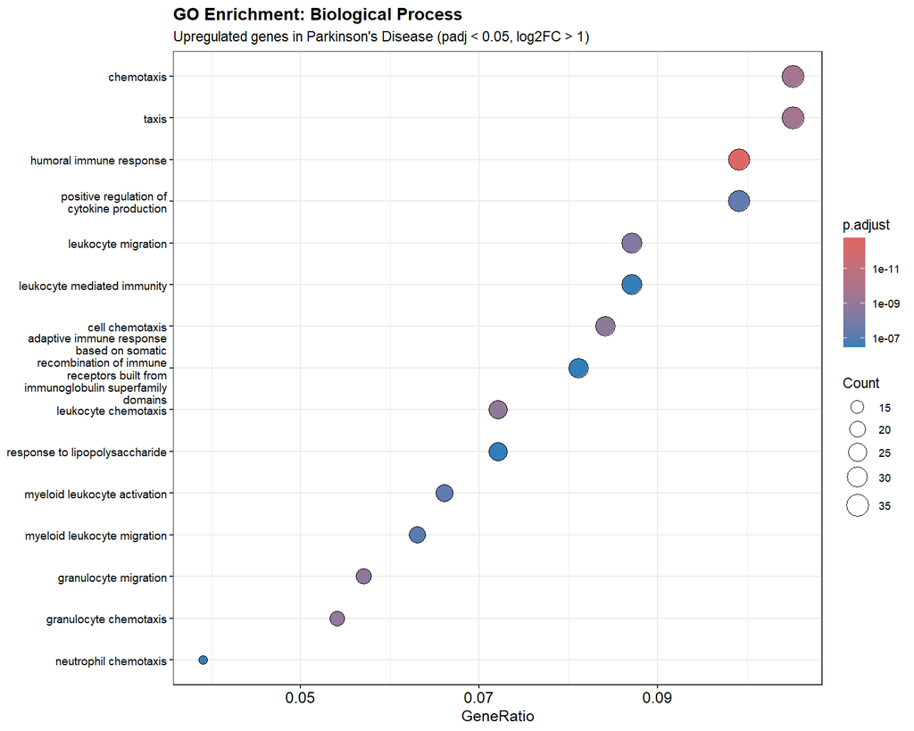

**Figure 8: GO Biological Process enrichment dotplot.** Each dot represents one enriched GO term among upregulated genes in Parkinson’s Disease. Dot size indicates the number of DEGs annotated to that term; color reflects statistical significance (adjusted p-value). Terms are ranked by gene ratio (proportion of DEGs in that term).

```r
dotplot(ego, showCategory = 15) +
  labs(
    title    = "GO Enrichment: Biological Process",
    subtitle = "Upregulated genes in Parkinson's Disease (padj < 0.05, log2FC > 1)"
  ) +
  theme(
    plot.title    = element_text(face = "bold"),
    axis.text.y   = element_text(size = 9)
  )
```

# GO Network Plot

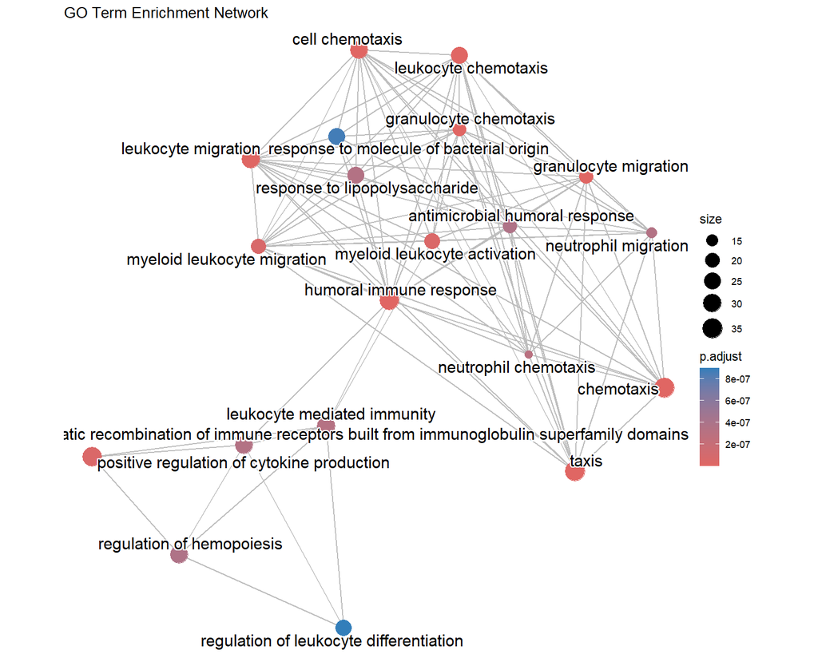

**Figure 9: GO enrichment network (emap plot).** Nodes represent enriched GO terms; edges connect terms that share annotated genes (Jaccard similarity). Tightly connected clusters indicate groups of biologically related processes. Node color reflects adjusted p-value and size reflects gene count.

```r
# Pairwise enrichment map: shows relationships between GO terms
emapplot(
  pairwise_termsim(ego),
  showCategory = 20
) +
  labs(title = "GO Term Enrichment Network")
```

> **Interpretation:** The enrichment map reveals functional modules among the enriched GO terms. Terms that share many genes appear connected, forming biological clusters. This helps identify higher-level biological themes (example: a cluster of terms all related to mitochondrial metabolism) rather than interpreting each GO term in isolation.

# GO Enrichment: Downregulated Genes

```r
# Extract Entrez IDs for significantly downregulated genes in Parkinson's Disease
genes_down <- sig_genes %>%
  filter(log2FoldChange < -1, !is.na(ENTREZID)) %>%
  pull(ENTREZID)

cat("Number of downregulated genes used for GO enrichment:", length(genes_down), "\n")
```

```
## Number of downregulated genes used for GO enrichment: 139
```

```r
# Run GO enrichment on downregulated genes (Biological Process ontology)
# Using the same parameters as the upregulated analysis for consistency
ego_down <- enrichGO(
  gene          = genes_down,
  OrgDb         = org.Hs.eg.db,
  keyType       = "ENTREZID",
  ont           = "BP",           # Biological Process
  pAdjustMethod = "BH",
  pvalueCutoff  = 0.05,
  readable      = TRUE            # Convert Entrez IDs to gene symbols in output
)

# Preview the top enriched GO terms for downregulated genes
head(as.data.frame(ego_down)[, c("Description", "GeneRatio", "BgRatio", "p.adjust", "Count")])
```

```
##                                                                        Description
## GO:0007218                                          neuropeptide signaling pathway
## GO:0050804                            modulation of chemical synaptic transmission
## GO:0099177                                  regulation of trans-synaptic signaling
## GO:0042391                                        regulation of membrane potential
## GO:0007610                                                                behavior
## GO:0007200 phospholipase C-activating G protein-coupled receptor signaling pathway
##            GeneRatio   BgRatio     p.adjust Count
## GO:0007218    11/123 115/18842 7.944523e-07    11
## GO:0050804    19/123 486/18842 7.944523e-07    19
## GO:0099177    19/123 488/18842 7.944523e-07    19
## GO:0042391    16/123 419/18842 2.129467e-05    16
## GO:0007610    15/123 400/18842 6.323540e-05    15
## GO:0007200    10/123 158/18842 8.430659e-05    10
```